# Contest One

## Data Cleaning

- Corrected metadata for variables
  - Date variables turned into date types instead of characters
  - etc.
- Filled in missing values
  - Specific customer means or modes
  - Entire population means or modes
- Corrected text data
  - Grouped colors together and spellchecked
  - Got rid of "+" on size variables
  - Got rid of white spaces

## Exploratory Data Analysis

- Looked at the structure of the data
- Looked at return percentages for each level of factor variables
- Example:

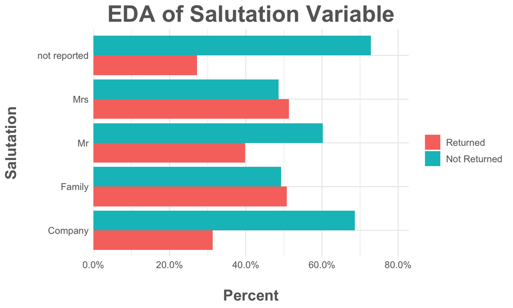

## Feature Engineering

- Creating features helps find latent variables that can increase accuracy
- Variables created:
  - **Age** (order date - date of birth)
  - **Time of Delivery** (delivery date - order date)
  - **Young/Old** (Age > 42)
  - …
- Binning/factoring of numeric variables
  - Prices into bins (e.g. $0 - $10 \(\Rightarrow\) 1, $10 - $20 \(\Rightarrow\) 2, etc.)
  - Age into bins (e.g. 10 - 20 \(\Rightarrow\) 1, 20 - 30 \(\Rightarrow\) 2, etc.)

## Modeling Attempts

- Ran multiple models at the beginning to see how accurate the classifiers would get
  - Tree and RandomForest
  - Logistic Regression
  - C5.0, xgboost, gbm
- This step helped determine which variables were most important/significant
  - Found out size and color were not important predictors

## Final Model

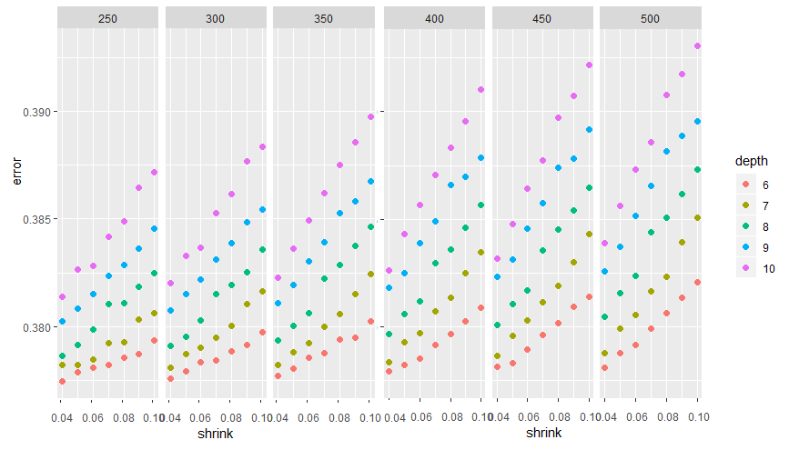

## Final Model Cont.

- We ran a 10 fold cross validation
  - For each fold we ran the test set to receive predictions

| ID | Fold One Prediction | Fold Two Prediction | … | Fold Ten Prediction |
| --- | --- | --- | --- | --- |
| 1 | .545 | .653 | … | .435 |
| 2 | .453 | .542 | … | .398 |
| 3 | .876 | .805 | … | .932 |
| … | … | … | … | … |
| 36337 | .301 | .192 | … | .254 |

## Final Results

- Voting system determined final prediction
- No delivery date, prediction was changed to 0

| ID | Fold One Prediction | Fold Two Prediction | … | Fold Ten Prediction | Mean Prediction | Final Vote |
| --- | --- | --- | --- | --- | --- | --- |
| 1 | .545 | .653 | … | .435 | .532 | 1 |
| 2 | .453 | .542 | … | .398 | .465 | 0 |
| 3 | .876 | .805 | … | .932 | .896 | 1 |
| … | … | … | … | … | … | … |
| 36337 | .301 | .192 | … | .254 | .222 | 0 |

- Predicted **19,098** returns (out of 36,337 items)
- Final model had a **.67575** accuracy rate